# Neurosurgery survey

Pavel Dusek

14 12 2023

## Software Info

Built with R version 4.3.2, dplyr version 1.1.3, tidyr version 1.3.0, ggplot2 version 3.4.3.

## Loading and Cleaning Data

We load the dataset:

```r
df <- read.csv("palliative_neurosurgery_survey.csv")
```

Order factors

```r
df <- df %>% mutate(
 Demographics_On_Call = factor(Demographics_On_Call, levels = c( "<3 days a month", "3-5 days a month", "5-10 days a month ", ">10 days a month")),
 Demographics_years_of_practise = factor(Demographics_years_of_practise, levels = c( "<5", "5-10", "10-20", ">20" )),
 Futile_Surgery = factor(Futile_Surgery, levels = c( "Never", "Rarely (once a year)", "Sometimes (2-5 a year)", "Often (>5 a year)" )),
 Burnout = factor(Burnout, levels = c( "NO", "MAYBE", "YES" )),
 Moral_Distress_Experience = factor(Moral_Distress_Experience, levels = c( "Strongly disagree", "Generally disagree", "Generally agree", "Strongly agree" )),
 Leaving_Position = factor(Leaving_Position, levels = c( "No, I have never considered leaving or left a position.", "Yes, I considered leaving but did not leave.", "Yes, I left a position.")),
 Communication_Training_Comfortability = factor( Communication_Training_Comfortability, levels = c( "None at all", "A little", "A moderate amount", "A lot", "A great deal" ) ),
 OLBI_result = factor( OLBI_result, levels = c("Not burned out", "At risk", "Burned out") )
)
```

Custom function to print out descriptive statistics:

```r
describe <- function( df, column_names, caption ) {
 df %>%
 as_tibble() %>%
 select( all_of(column_names) ) %>%
 pivot_longer( cols = all_of(column_names) ) %>%
 group_by(name) %>%
 summarize_at(
  .vars = vars(value),
  .funs = list(
   min = min,
   Q1 = ~quantile(., probs = 0.25),
   median = median,
   Q3 = ~quantile(., probs = 0.75),
   max= max,
   mean = ~round(mean(.), digits = 2),
   sd = ~round(sd(.), digits = 2)
  )
 ) %>%
 kable( caption = caption )
}

frequency_table <- function( df, variable ) {
 df %>%
 select_at( variable ) %>%
 group_by_at( variable ) %>%
 count() %>%
 mutate( perc = round( (100 * n )/dim(df)[1], digits = 2) ) %>%
 kable( caption = paste( variable, "Counts" ) )
}

describe_univariate <- function( df, variable ) {
 df %>%
 select( all_of( c(variable, "Moral_Distress_Score") ) ) %>%
 group_by_at(variable) %>%
 summarize_at(
  vars(Moral_Distress_Score),
  .funs = list(
   min = min,
   Q1 = ~quantile(., probs = 0.25),
   median = median,
   Q3 = ~quantile(., probs=0.75),
   max= max,
   mean = ~round(mean(.), digits=2),
   sd = ~round(sd(.), digits=2)
  )
 ) %>%
 arrange( desc( median ) ) %>%
 kable( caption = paste("Moral Distress grouped by", variable ) )
}

plot_univariate <- function( df, variable ) {
 ggplot( df, aes( x = .data[[variable]], y = Moral_Distress_Score) ) +
 geom_violin(trim = FALSE) +
 geom_boxplot( width = 0.1 ) +
 ggtitle( paste( "Moral Distress Score by", variable ) )
}
```

## Oldenburg Burnout Inventory (OLBI)

```r
describe( df = df, column_names = c("OLBI_mean", "OLBI_D_mean", "OLBI_E_mean"), caption = "OLBI Descriptive Statistics" )
```

OLBI Descriptive Statistics

| name | min | Q1 | median | Q3 | max | mean | sd |
| --- | --- | --- | --- | --- | --- | --- | --- |
| OLBI_D_mean | 1.250 | 1.906250 | 2.18750 | 2.625 | 3.125 | 2.26 | 0.49 |
| OLBI_E_mean | 1.375 | 1.875000 | 2.50000 | 2.875 | 3.375 | 2.41 | 0.56 |
| OLBI_mean | 1.375 | 1.890625 | 2.40625 | 2.750 | 3.125 | 2.33 | 0.50 |

## Moral Distress Description

### Total Score and Subscores

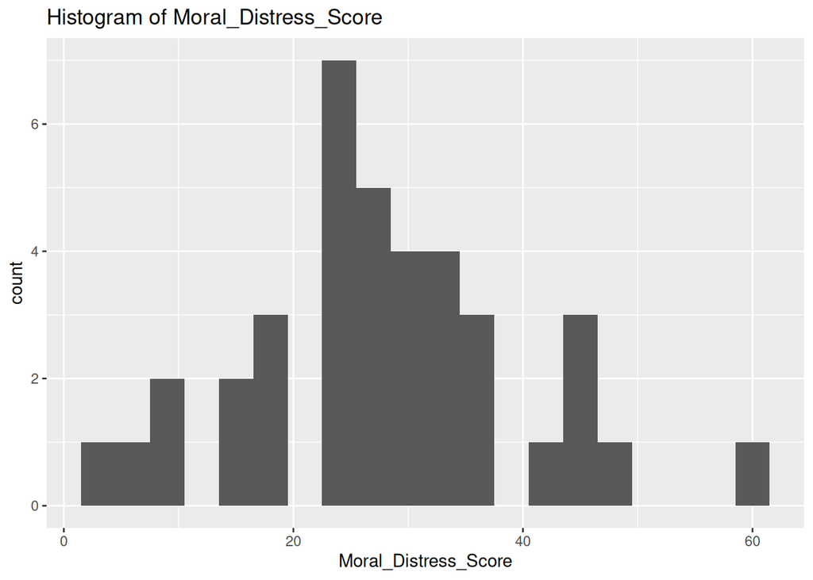

```r
ggplot( df, aes( x = Moral_Distress_Score ) ) +
 geom_histogram( bins = 20 ) +
 ggtitle( "Histogram of Moral_Distress_Score" )
```

```r
describe(
    df = df,
    column_names = c("Moral_Distress_Score", "Moral_Distress_Score_frequency", "Moral_Distress_Score_intensity"),
    caption = "Moral Distress Score Descriptive Statistics"
)
```

Moral Distress Score Descriptive Statistics

| name | min | Q1 | median | Q3 | max | mean | sd |
| --- | --- | --- | --- | --- | --- | --- | --- |
| Moral_Distress_Score | 2 | 23 | 27 | 33.75 | 59 | 27.55 | 12.02 |
| Moral_Distress_Score_frequency | 2 | 7 | 10 | 14.75 | 27 | 11.24 | 5.76 |
| Moral_Distress_Score_intensity | 0 | 11 | 17 | 23.00 | 32 | 16.32 | 7.64 |

### Each Question Frequency

```r
frequency_columns <- c(
    "Moral_Distress_1_frequency",
    "Moral_Distress_2_frequency",
    "Moral_Distress_3_frequency",
    "Moral_Distress_4_frequency",
    "Moral_Distress_5_frequency",
    "Moral_Distress_6_frequency",
    "Moral_Distress_7_frequency",
    "Moral_Distress_8_frequency"
)
describe(
     df = df,
     column_names = frequency_columns,
     caption = "Moral Distress Frequency Questions Descriptive Statistics"
)
```

Moral Distress Frequency Questions Descriptive Statistics

| name | min | Q1 | median | Q3 | max | mean | sd |
| --- | --- | --- | --- | --- | --- | --- | --- |
| Moral_Distress_1_frequency | 0 | 1.00 | 1 | 2.00 | 4 | 1.26 | 0.92 |
| Moral_Distress_2_frequency | 0 | 1.00 | 1 | 2.00 | 4 | 1.29 | 0.93 |
| Moral_Distress_3_frequency | 0 | 1.00 | 1 | 2.75 | 4 | 1.58 | 1.11 |
| Moral_Distress_4_frequency | 0 | 1.00 | 1 | 2.00 | 3 | 1.55 | 0.89 |
| Moral_Distress_5_frequency | 0 | 1.00 | 1 | 2.00 | 4 | 1.42 | 1.08 |
| Moral_Distress_6_frequency | 0 | 1.00 | 1 | 2.00 | 4 | 1.66 | 1.17 |
| Moral_Distress_7_frequency | 0 | 0.25 | 1 | 2.00 | 4 | 1.16 | 0.95 |
| Moral_Distress_8_frequency | 0 | 0.25 | 1 | 2.00 | 4 | 1.32 | 1.21 |

Questions sorted by mean frequency (highest to lowest):

```r
df %>% as_tibble() %>% select( all_of( frequency_columns ) ) %>% pivot_longer( all_of(frequency_columns) ) %>% group_by( name ) %>% summarize( mean = mean(value) ) %>% arrange( desc(mean) ) %>% select( name )
```

```
## # A tibble: 8 × 1
##   name
##   <chr>
## 1 Moral_Distress_6_frequency
## 2 Moral_Distress_3_frequency
## 3 Moral_Distress_4_frequency
## 4 Moral_Distress_5_frequency
## 5 Moral_Distress_8_frequency
## 6 Moral_Distress_2_frequency
## 7 Moral_Distress_1_frequency
## 8 Moral_Distress_7_frequency
```

### Each Question Intensity

```r
intensity_columns <- c(
    "Moral_Distress_1_intensity",
    "Moral_Distress_2_intensity",
    "Moral_Distress_3_intensity",
    "Moral_Distress_4_intensity",
    "Moral_Distress_5_intensity",
    "Moral_Distress_6_intensity",
    "Moral_Distress_7_intensity",
    "Moral_Distress_8_intensity"
)
describe(
     df = df,
     column_names = intensity_columns,
     caption = "Moral Distress Intensity Questions Descriptive Statistics"
)
```

Moral Distress Intensity Questions Descriptive Statistics

| name | min | Q1 | median | Q3 | max | mean | sd |
| --- | --- | --- | --- | --- | --- | --- | --- |
| Moral_Distress_1_intensity | 0 | 1 | 2 | 3 | 4 | 1.84 | 1.28 |
| Moral_Distress_2_intensity | 0 | 1 | 2 | 3 | 4 | 2.05 | 1.18 |
| Moral_Distress_3_intensity | 0 | 1 | 2 | 3 | 4 | 2.16 | 1.13 |
| Moral_Distress_4_intensity | 0 | 1 | 2 | 3 | 4 | 2.11 | 1.18 |
| Moral_Distress_5_intensity | 0 | 1 | 2 | 3 | 4 | 2.21 | 1.23 |
| Moral_Distress_6_intensity | 0 | 1 | 2 | 3 | 4 | 1.95 | 1.14 |
| Moral_Distress_7_intensity | 0 | 1 | 2 | 3 | 4 | 2.16 | 1.28 |
| Moral_Distress_8_intensity | 0 | 1 | 2 | 2 | 4 | 1.84 | 1.20 |

Questions sorted by mean intensity (highest to lowest):

```r
df %>% as_tibble() %>% select( all_of( intensity_columns ) ) %>% pivot_longer( all_of(intensity_columns) ) %>% group_by( name ) %>% summarize( mean = mean(value) ) %>% arrange( desc(mean) ) %>% select( name )
```

```
## # A tibble: 8 × 1
##   name
##   <chr>
## 1 Moral_Distress_5_intensity
## 2 Moral_Distress_3_intensity
## 3 Moral_Distress_7_intensity
## 4 Moral_Distress_4_intensity
## 5 Moral_Distress_2_intensity
## 6 Moral_Distress_6_intensity
## 7 Moral_Distress_1_intensity
## 8 Moral_Distress_8_intensity
```

## Moral Distress Univariate Analysis

### Gender

```r
frequency_table( df, "Demographics_gender" )
```

Demographics_gender Counts

| Demographics_gender | n | perc |
| --- | --- | --- |
| Decline to answer | 2 | 5.26 |
| Female | 5 | 13.16 |
| Male | 31 | 81.58 |

```r
describe_univariate( df, "Demographics_gender" )
```

Moral Distress grouped by Demographics_gender

| Demographics_gender | min | Q1 | median | Q3 | max | mean | sd |
| --- | --- | --- | --- | --- | --- | --- | --- |
| Decline to answer | 36 | 38 | 40 | 42.0 | 44 | 40.00 | 5.66 |
| Female | 17 | 29 | 29 | 32.0 | 44 | 30.20 | 9.63 |
| Male | 2 | 21 | 26 | 32.5 | 59 | 26.32 | 12.31 |

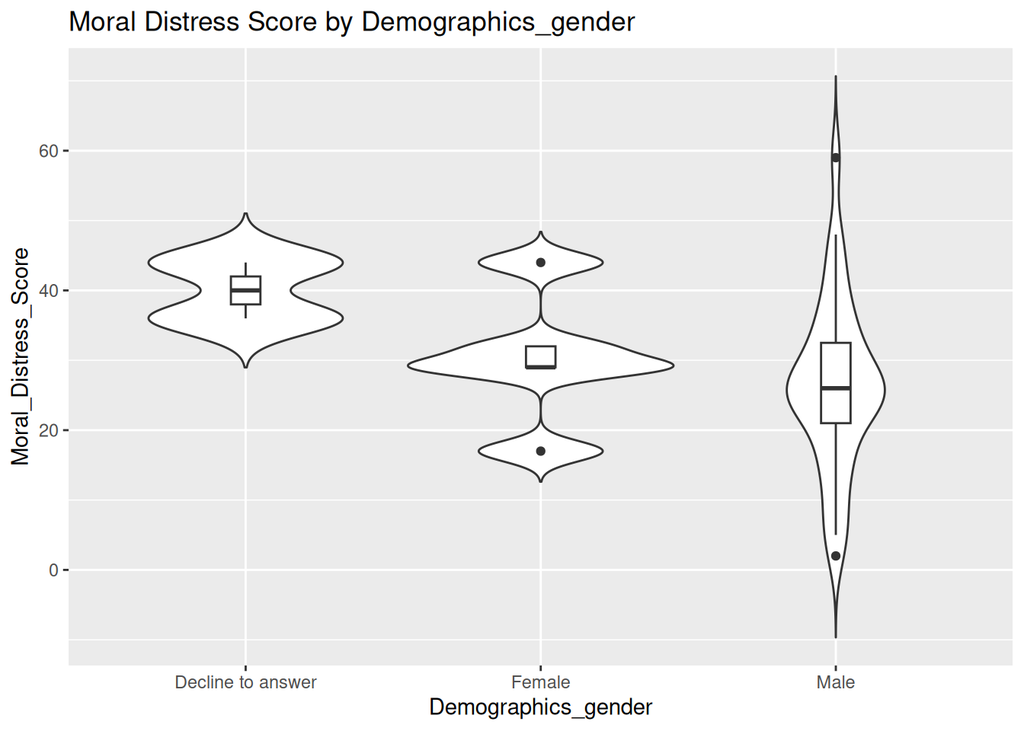

```r
plot_univariate( df, "Demographics_gender" )
```

```r
wilcox.test(
    Moral_Distress_Score ~ Demographics_gender,
    data = df %>%
        select( Moral_Distress_Score, Demographics_gender ) %>%
        filter( Demographics_gender != "Decline to answer")
)
```

```
##
##  Wilcoxon rank sum test with continuity correction
##
## data:  Moral_Distress_Score by Demographics_gender
## W = 98.5, p-value = 0.3479
## alternative hypothesis: true location shift is not equal to 0
```

### Years of practice

```r
frequency_table( df, "Demographics_years_of_practise" )
```

Demographics_years_of_practise Counts

| Demographics_years_of_practise | n | perc |
| --- | --- | --- |
| <5 | 3 | 7.89 |
| 5-10 | 7 | 18.42 |
| 10-20 | 11 | 28.95 |
| >20 | 16 | 42.11 |
| NA | 1 | 2.63 |

```r
describe_univariate( df, "Demographics_years_of_practise" )
```

Moral Distress grouped by Demographics_years_of_practise

| Demographics_years_of_practise | min | Q1 | median | Q3 | max | mean | sd |
| --- | --- | --- | --- | --- | --- | --- | --- |
| NA | 44 | 44.0 | 44.0 | 44.0 | 44 | 44.00 | NA |
| <5 | 29 | 31.5 | 34.0 | 39.0 | 44 | 35.67 | 7.64 |
| 10-20 | 2 | 24.5 | 29.0 | 38.5 | 59 | 30.73 | 15.53 |
| 5-10 | 17 | 20.0 | 28.0 | 37.0 | 44 | 29.00 | 10.63 |
| >20 | 5 | 18.0 | 24.5 | 27.5 | 32 | 22.19 | 8.49 |

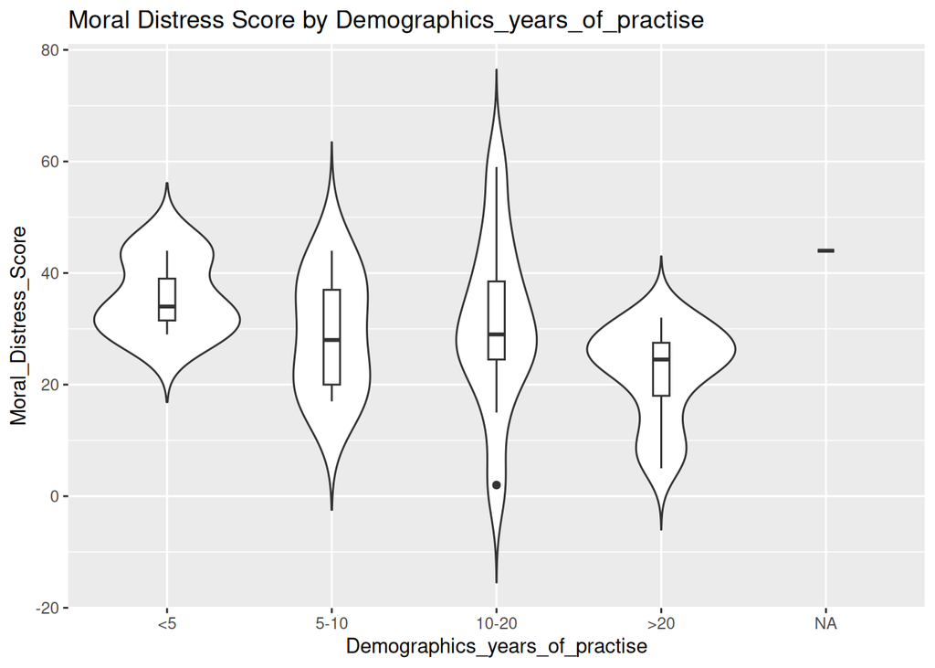

```r
plot_univariate( df, "Demographics_years_of_practise" )
```

```r
kruskal.test(
    Moral_Distress_Score ~ Demographics_years_of_practise,
    data = df %>% filter( Demographics_years_of_practise != "Decline to answer" )
)
```

```
##
##  Kruskal-Wallis rank sum test
##
## data:  Moral_Distress_Score by Demographics_years_of_practise
## Kruskal-Wallis chi-squared = 6.1604, df = 3, p-value = 0.1041
```

### Position

```r
frequency_table( df, "Demographics_position" )
```

Demographics_position Counts

| Demographics_position | n | perc |
| --- | --- | --- |
| Attending neurosurgeon | 25 | 65.79 |
| Resident | 13 | 34.21 |

```r
describe_univariate( df, "Demographics_position" )
```

Moral Distress grouped by Demographics_position

| Demographics_position | min | Q1 | median | Q3 | max | mean | sd |
| --- | --- | --- | --- | --- | --- | --- | --- |
| Resident | 15 | 23 | 29 | 33 | 44 | 28.31 | 9.36 |
| Attending neurosurgeon | 2 | 23 | 26 | 36 | 59 | 27.16 | 13.35 |

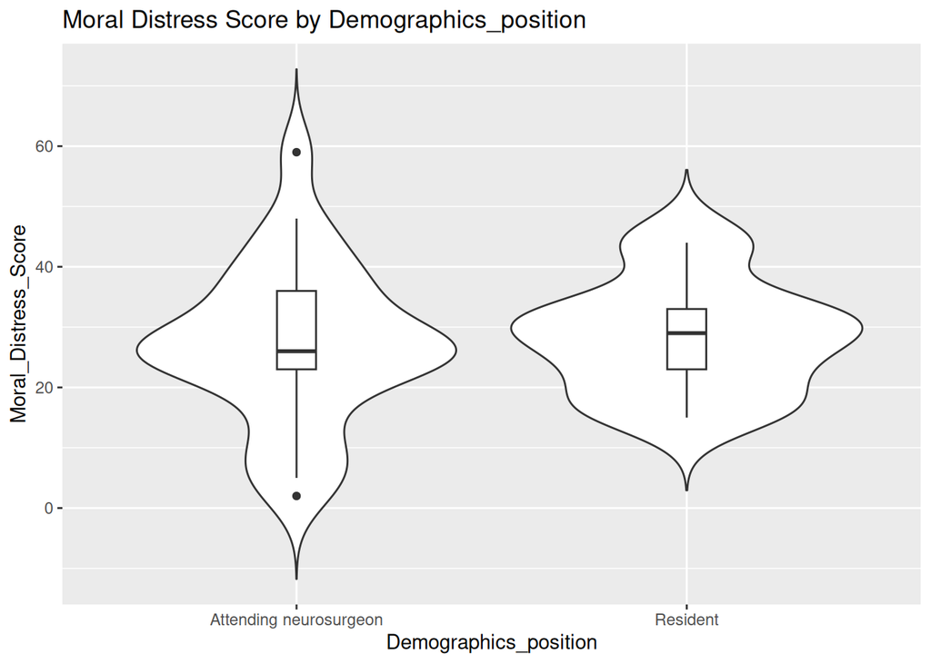

```r
plot_univariate( df, "Demographics_position" )
```

```r
wilcox.test(
    Moral_Distress_Score ~ Demographics_position,
    data = df
)
```

```
##
##  Wilcoxon rank sum test with continuity correction
##
## data:  Moral_Distress_Score by Demographics_position
## W = 153, p-value = 0.7816
## alternative hypothesis: true location shift is not equal to 0
```

### Trauma Center

```r
frequency_table( df, "Demographics_Trauma_Center" )
```

Demographics_Trauma_Center Counts

| Demographics_Trauma_Center | n | perc |
| --- | --- | --- |
| Decline to answer | 1 | 2.63 |
| NO | 4 | 10.53 |
| YES | 33 | 86.84 |

```r
describe_univariate( df, "Demographics_Trauma_Center" )
```

Moral Distress grouped by Demographics_Trauma_Center

| Demographics_Trauma_Center | min | Q1 | median | Q3 | max | mean | sd |
| --- | --- | --- | --- | --- | --- | --- | --- |
| Decline to answer | 44 | 44.00 | 44.0 | 44.00 | 44 | 44.00 | NA |
| YES | 2 | 23.00 | 28.0 | 34.00 | 59 | 28.21 | 11.86 |
| NO | 8 | 13.25 | 19.5 | 24.25 | 25 | 18.00 | 8.04 |

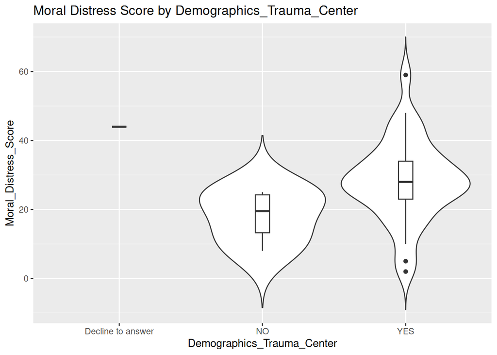

```r
plot_univariate( df, "Demographics_Trauma_Center" )
```

```r
wilcox.test(
    Moral_Distress_Score ~ Demographics_Trauma_Center,
    data = df %>% filter( Demographics_Trauma_Center != "Decline to answer" )
)
```

```
##
##  Wilcoxon rank sum test with continuity correction
##
## data:  Moral_Distress_Score by Demographics_Trauma_Center
## W = 27.5, p-value = 0.06281
## alternative hypothesis: true location shift is not equal to 0
```

### On Call

```r
frequency_table( df, "Demographics_On_Call" )
```

Demographics_On_Call Counts

| Demographics_On_Call | n | perc |
| --- | --- | --- |
| <3 days a month | 3 | 7.89 |
| 3-5 days a month | 18 | 47.37 |
| 5-10 days a month | 14 | 36.84 |
| >10 days a month | 2 | 5.26 |
| NA | 1 | 2.63 |

```r
describe_univariate( df, "Demographics_On_Call" )
```

Moral Distress grouped by Demographics_On_Call

| Demographics_On_Call | min | Q1 | median | Q3 | max | mean | sd |
| --- | --- | --- | --- | --- | --- | --- | --- |
| NA | 36 | 36.00 | 36.0 | 36.00 | 36 | 36.00 | NA |
| <3 days a month | 19 | 24.00 | 29.0 | 29.50 | 30 | 26.00 | 6.08 |
| 3-5 days a month | 8 | 25.00 | 28.5 | 37.00 | 59 | 31.06 | 12.19 |
| 5-10 days a month | 2 | 17.00 | 25.0 | 32.75 | 44 | 23.93 | 12.67 |
| >10 days a month | 15 | 17.25 | 19.5 | 21.75 | 24 | 19.50 | 6.36 |

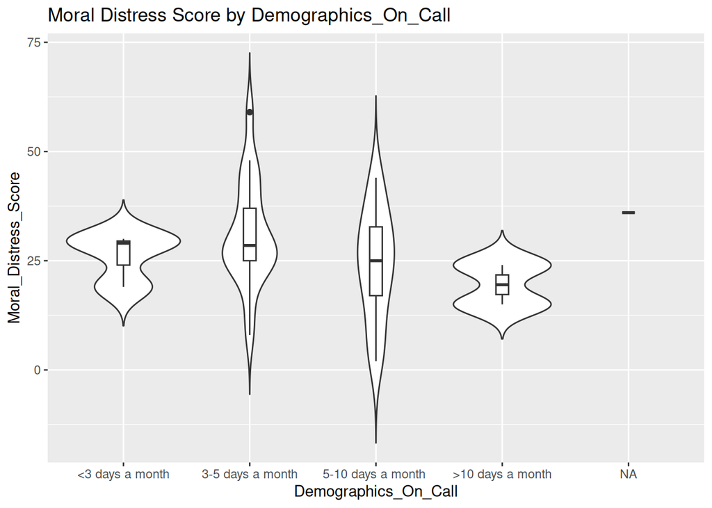

```r
plot_univariate( df, "Demographics_On_Call" )
```

```r
kruskal.test(
    Moral_Distress_Score ~ Demographics_On_Call,
    data = df %>% filter( Demographics_On_Call != "Decline to answer" )
)
```

```
##
##  Kruskal-Wallis rank sum test
##
## data:  Moral_Distress_Score by Demographics_On_Call
## Kruskal-Wallis chi-squared = 3.4948, df = 3, p-value = 0.3214
```

### Futile Surgery Frequency

```r
frequency_table( df, "Futile_Surgery" )
```

Futile_Surgery Counts

| Futile_Surgery | n | perc |
| --- | --- | --- |
| Never | 2 | 5.26 |
| Rarely (once a year) | 8 | 21.05 |
| Sometimes (2-5 a year) | 17 | 44.74 |
| Often (>5 a year) | 11 | 28.95 |

```r
describe_univariate( df, "Futile_Surgery" )
```

Moral Distress grouped by Futile_Surgery

| Futile_Surgery | min | Q1 | median | Q3 | max | mean | sd |
| --- | --- | --- | --- | --- | --- | --- | --- |
| Rarely (once a year) | 2 | 22.25 | 29.5 | 32.50 | 37 | 24.62 | 13.37 |
| Often (>5 a year) | 10 | 23.00 | 27.0 | 38.00 | 44 | 28.64 | 11.58 |
| Sometimes (2-5 a year) | 15 | 23.00 | 26.0 | 36.00 | 59 | 29.06 | 11.77 |
| Never | 8 | 14.25 | 20.5 | 26.75 | 33 | 20.50 | 17.68 |

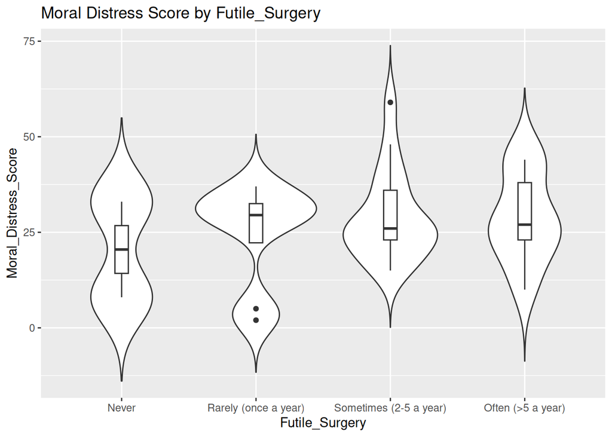

```r
plot_univariate( df, "Futile_Surgery" )
```

```r
  kruskal.test(
    Moral_Distress_Score ~ Futile_Surgery,
    data = df
  )
```

```
##
##  Kruskal-Wallis rank sum test
##
## data:  Moral_Distress_Score by Futile_Surgery
## Kruskal-Wallis chi-squared = 0.28387, df = 3, p-value = 0.963
```

### Burnout self-assessment

```r
frequency_table( df, "Burnout" )
```

Burnout Counts

| Burnout | n | perc |
| --- | --- | --- |
| NO | 15 | 39.47 |
| MAYBE | 14 | 36.84 |
| YES | 9 | 23.68 |

```r
describe_univariate( df, "Burnout" )
```

Moral Distress grouped by Burnout

| Burnout | min | Q1 | median | Q3 | max | mean | sd |
| --- | --- | --- | --- | --- | --- | --- | --- |
| YES | 5 | 29 | 33.0 | 41 | 48 | 32.22 | 12.89 |
| NO | 8 | 21 | 26.0 | 29 | 37 | 24.93 | 7.41 |
| MAYBE | 2 | 17 | 25.5 | 35 | 59 | 27.36 | 15.05 |

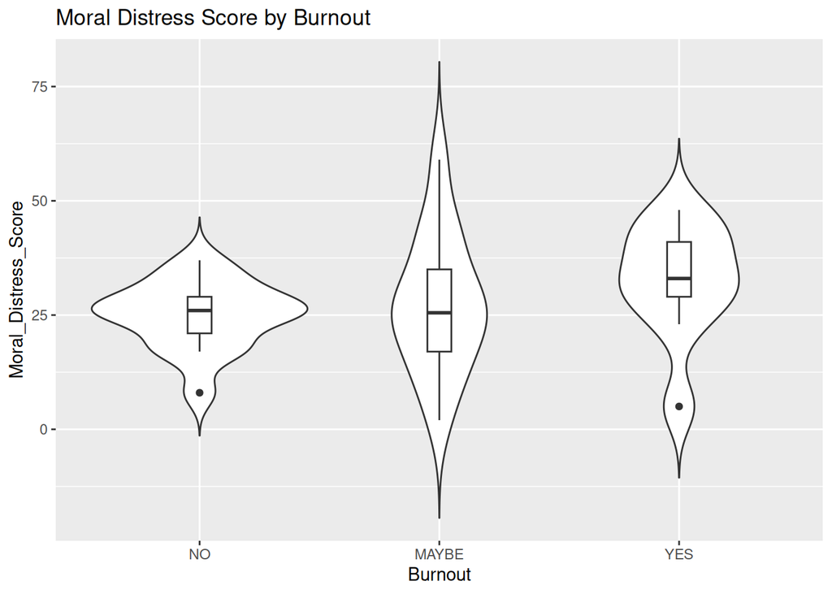

```r
plot_univariate( df, "Burnout" )
```

```r
  kruskal.test(
    Moral_Distress_Score ~ Burnout,
    data = df
  )
```

```
##
##  Kruskal-Wallis rank sum test
##
## data:  Moral_Distress_Score by Burnout
## Kruskal-Wallis chi-squared = 3.0689, df = 2, p-value = 0.2156
```

### Burnout by OLBI

```r
frequency_table( df, "OLBI_result" )
```

OLBI_result Counts

| OLBI_result | n | perc |
| --- | --- | --- |
| Not burned out | 12 | 31.58 |
| At risk | 5 | 13.16 |
| Burned out | 21 | 55.26 |

```r
describe_univariate( df, "OLBI_result" )
```

Moral Distress grouped by OLBI_result

| OLBI_result | min | Q1 | median | Q3 | max | mean | sd |
| --- | --- | --- | --- | --- | --- | --- | --- |
| Burned out | 2 | 24.0 | 29.0 | 41.00 | 59 | 30.9 | 13.58 |
| At risk | 17 | 23.0 | 25.0 | 26.00 | 37 | 25.6 | 7.27 |
| Not burned out | 5 | 18.5 | 24.5 | 27.75 | 34 | 22.5 | 8.94 |

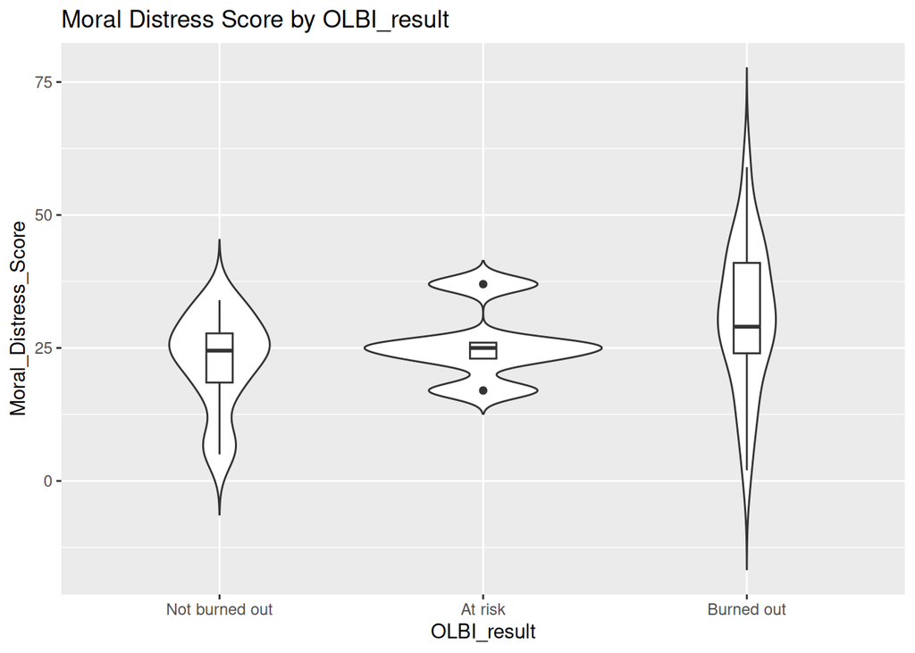

```r
plot_univariate( df, "OLBI_result" )
```

```r
  kruskal.test(
    Moral_Distress_Score ~ OLBI_result,
    data = df
  )
```

```
##
##  Kruskal-Wallis rank sum test
##
## data:  Moral_Distress_Score by OLBI_result
## Kruskal-Wallis chi-squared = 4.2534, df = 2, p-value = 0.1192
```

### Experienced moral distress during last year

```r
frequency_table( df, "Moral_Distress_Experience" )
```

Moral_Distress_Experience Counts

| Moral_Distress_Experience | n | perc |
| --- | --- | --- |
| Strongly disagree | 6 | 15.79 |
| Generally disagree | 10 | 26.32 |
| Generally agree | 17 | 44.74 |
| Strongly agree | 5 | 13.16 |

```r
describe_univariate( df, "Moral_Distress_Experience" )
```

Moral Distress grouped by Moral_Distress_Experience

| Moral_Distress_Experience | min | Q1 | median | Q3 | max | mean | sd |
| --- | --- | --- | --- | --- | --- | --- | --- |
| Strongly agree | 24 | 32.00 | 44 | 44.00 | 44 | 37.60 | 9.21 |
| Generally agree | 5 | 23.00 | 29 | 36.00 | 59 | 29.06 | 11.77 |
| Generally disagree | 10 | 23.50 | 27 | 31.25 | 48 | 27.00 | 10.40 |
| Strongly disagree | 2 | 10.25 | 17 | 23.00 | 26 | 15.83 | 9.41 |

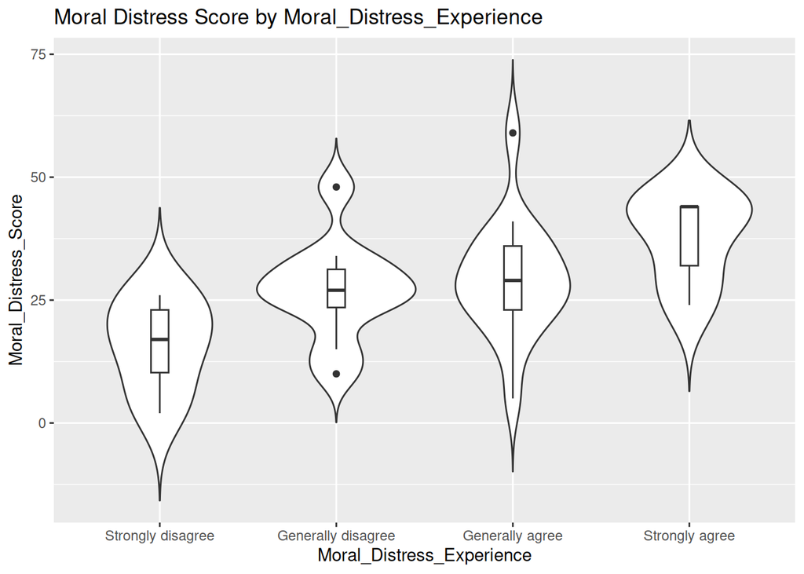

```r
plot_univariate( df, "Moral_Distress_Experience" )
```

```r
kruskal.test(
    Moral_Distress_Score ~ Moral_Distress_Experience,
    data = df
)
```

```
##
##  Kruskal-Wallis rank sum test
##
## data:  Moral_Distress_Score by Moral_Distress_Experience
## Kruskal-Wallis chi-squared = 9.6381, df = 3, p-value = 0.02191
```

### Leaving a position because of moral distress

```r
frequency_table( df, "Leaving_Position" )
```

Leaving_Position Counts

| Leaving_Position | n | perc |
| --- | --- | --- |
| No, I have never considered leaving or left a position. | 28 | 73.68 |
| Yes, I considered leaving but did not leave. | 8 | 21.05 |
| Yes, I left a position. | 2 | 5.26 |

```r
describe_univariate( df, "Leaving_Position" )
```

Moral Distress grouped by Leaving_Position

| Leaving_Position | min | Q1 | median | Q3 | max | mean | sd |
| --- | --- | --- | --- | --- | --- | --- | --- |
| Yes, I left a position. | 25 | 29.75 | 34.5 | 39.25 | 44 | 34.50 | 13.44 |
| Yes, I considered leaving but did not leave. | 15 | 25.50 | 28.0 | 41.75 | 44 | 31.25 | 10.61 |
| No, I have never considered leaving or left a position. | 2 | 18.50 | 26.5 | 32.25 | 59 | 26.00 | 12.32 |

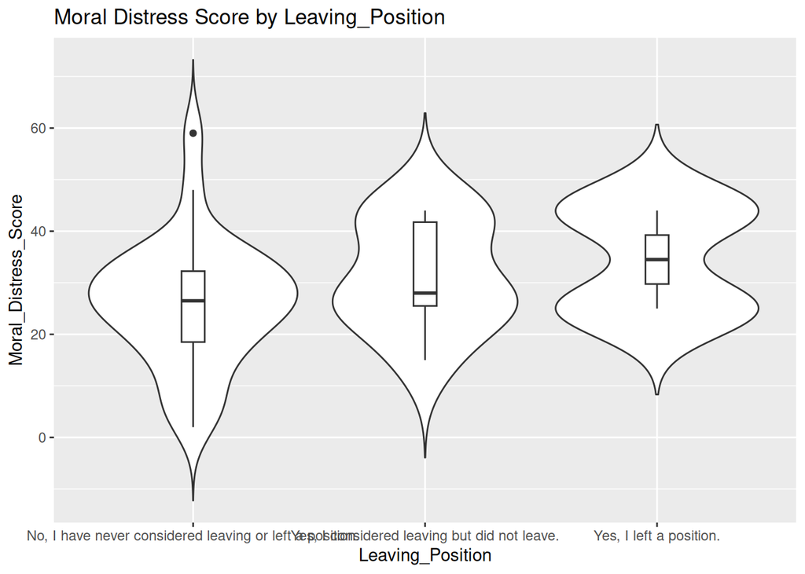

```r
plot_univariate( df, "Leaving_Position" )
```

```r
kruskal.test(
    Moral_Distress_Score ~ Leaving_Position,
    data = df
)
```

```
##
##  Kruskal-Wallis rank sum test
##
## data:  Moral_Distress_Score by Leaving_Position
## Kruskal-Wallis chi-squared = 1.6299, df = 2, p-value = 0.4427
```

## Multivariate Regression Analysis of Moral Distress Score

Without grouping of categories, OLBI categorical (interpretation).

```r
model <- lm(
   Moral_Distress_Score ~ Demographics_years_of_practise + Trauma_Center + Futile_Surgery + OLBI_result + 1,
   data = df %>% mutate(
    Trauma_Center = ifelse( Demographics_Trauma_Center == 'YES', 'yes', 'no')
   )
)
summary(model)
```

```
##
## Call:
## lm(formula = Moral_Distress_Score ~ Demographics_years_of_practise +
##     Trauma_Center + Futile_Surgery + OLBI_result + 1, data = df %>%
##     mutate(Trauma_Center = ifelse(Demographics_Trauma_Center ==
##         "YES", "yes", "no")))
##
## Residuals:
##      Min       1Q   Median       3Q      Max
## -24.1329  -6.2765   0.8597   6.0139  25.2218
##
## Coefficients:
##                                      Estimate Std. Error t value Pr(>|t|)
## (Intercept)                           26.5816    12.2289   2.174   0.0387 *
## Demographics_years_of_practise5-10    -9.6602     8.6154  -1.121   0.2720
## Demographics_years_of_practise10-20   -9.1436     8.4949  -1.076   0.2913
## Demographics_years_of_practise>20    -13.9776     8.0021  -1.747   0.0921 .
## Trauma_Centeryes                       7.2543     6.8879   1.053   0.3016
## Futile_SurgeryRarely (once a year)    -2.2631    10.2042  -0.222   0.8262
## Futile_SurgerySometimes (2-5 a year)   5.3822     9.3207   0.577   0.5684
## Futile_SurgeryOften (>5 a year)        2.6112     9.8026   0.266   0.7920
## OLBI_resultAt risk                    -0.3291     6.9237  -0.048   0.9624
## OLBI_resultBurned out                  3.7038     5.1945   0.713   0.4820
## ---
## Signif. codes:  0 '***' 0.001 '**' 0.01 '*' 0.05 '.' 0.1 ' ' 1
##
## Residual standard error: 11.76 on 27 degrees of freedom
##   (1 observation deleted due to missingness)
## Multiple R-squared:  0.2629, Adjusted R-squared:  0.01721
## F-statistic:  1.07 on 9 and 27 DF,  p-value: 0.415
```

With grouping of categories, OLBI categorical (interpretation).

```r
model <- lm(
   Moral_Distress_Score ~ years_of_practise + Trauma_Center + Futile_Surgery + OLBI + 1,
   data = df %>% mutate(
    years_of_practise = ifelse( Demographics_years_of_practise %in% c('<5','5-10'), 'short', 'long'),
    Trauma_Center = ifelse( Demographics_Trauma_Center == 'YES', 'yes', 'no'),
    Futile_Surgery = ifelse( Futile_Surgery %in% c('Never', 'Rarely (once a year)'), 'no', 'yes'),
    OLBI = ifelse( OLBI_result == 'Burned out', 'yes', 'no')
   )
)
summary(model)
```

```
##
## Call:
## lm(formula = Moral_Distress_Score ~ years_of_practise + Trauma_Center +
##     Futile_Surgery + OLBI + 1, data = df %>% mutate(years_of_practise = ifelse(Demographics_years_of_practise %in%
##     c("<5", "5-10"), "short", "long"), Trauma_Center = ifelse(Demographics_Trauma_Center ==
##     "YES", "yes", "no"), Futile_Surgery = ifelse(Futile_Surgery %in%
##     c("Never", "Rarely (once a year)"), "no", "yes"), OLBI = ifelse(OLBI_result ==
##     "Burned out", "yes", "no")))
##
## Residuals:
##      Min       1Q   Median       3Q      Max
## -23.5164  -6.7123   0.7151   7.7033  27.8603
##
## Coefficients:
##                        Estimate Std. Error t value Pr(>|t|)
## (Intercept)              16.017      6.366   2.516   0.0169 *
## years_of_practiseshort    4.793      4.465   1.074   0.2908
## Trauma_Centeryes          2.789      5.754   0.485   0.6311
## Futile_Surgeryyes         5.623      4.358   1.290   0.2059
## OLBIyes                   6.710      3.821   1.756   0.0884 .
## ---
## Signif. codes:  0 '***' 0.001 '**' 0.01 '*' 0.05 '.' 0.1 ' ' 1
##
## Residual standard error: 11.59 on 33 degrees of freedom
## Multiple R-squared:  0.1702, Adjusted R-squared:  0.06966
## F-statistic: 1.693 on 4 and 33 DF,  p-value: 0.1752
```

Without grouping of categories, OLBI numerical (score).

```r
model <- lm(
   Moral_Distress_Score ~ Demographics_years_of_practise + Trauma_Center + Futile_Surgery + OLBI_mean + 1,
   data = df %>% mutate(
    Trauma_Center = ifelse( Demographics_Trauma_Center == 'YES', 'yes', 'no')
   )
)
summary(model)
```

```
##
## Call:
## lm(formula = Moral_Distress_Score ~ Demographics_years_of_practise +
##     Trauma_Center + Futile_Surgery + OLBI_mean + 1, data = df %>%
##     mutate(Trauma_Center = ifelse(Demographics_Trauma_Center ==
##         "YES", "yes", "no")))
##
## Residuals:
##     Min      1Q  Median      3Q     Max
## -25.316  -5.758   1.417   5.950  21.582
##
## Coefficients:
##                                      Estimate Std. Error t value Pr(>|t|)
## (Intercept)                            9.0377    14.6832   0.616   0.5432
## Demographics_years_of_practise5-10    -9.8424     7.9407  -1.239   0.2255
## Demographics_years_of_practise10-20   -9.6683     7.8611  -1.230   0.2290
## Demographics_years_of_practise>20    -11.9823     7.4755  -1.603   0.1202
## Trauma_Centeryes                       7.2745     6.3407   1.147   0.2610
## Futile_SurgeryRarely (once a year)    -2.7745     9.4990  -0.292   0.7724
## Futile_SurgerySometimes (2-5 a year)   4.6631     8.5579   0.545   0.5901
## Futile_SurgeryOften (>5 a year)        0.7341     9.0746   0.081   0.9361
## OLBI_mean                              8.5259     4.2869   1.989   0.0566 .
## ---
## Signif. codes:  0 '***' 0.001 '**' 0.01 '*' 0.05 '.' 0.1 ' ' 1
##
## Residual standard error: 10.94 on 28 degrees of freedom
##   (1 observation deleted due to missingness)
## Multiple R-squared:  0.3376, Adjusted R-squared:  0.1483
## F-statistic: 1.784 on 8 and 28 DF,  p-value: 0.1229
```

With grouping of categories, OLBI numerical (score).

```r
model <- lm(
   Moral_Distress_Score ~ years_of_practise + Trauma_Center + Futile_Surgery + OLBI_mean + 1,
   data = df %>% mutate(
    years_of_practise = ifelse( Demographics_years_of_practise %in% c('<5','5-10'), 'short', 'long'),
    Trauma_Center = ifelse( Demographics_Trauma_Center == 'YES', 'yes', 'no'),
    Futile_Surgery = ifelse( Futile_Surgery %in% c('Never', 'Rarely (once a year)'), 'no', 'yes')
   )
)
summary(model)
```

```
##
## Call:
## lm(formula = Moral_Distress_Score ~ years_of_practise + Trauma_Center +
##     Futile_Surgery + OLBI_mean + 1, data = df %>% mutate(years_of_practise = ifelse(Demographics_years_of_practise %in%
##     c("<5", "5-10"), "short", "long"), Trauma_Center = ifelse(Demographics_Trauma_Center ==
##     "YES", "yes", "no"), Futile_Surgery = ifelse(Futile_Surgery %in%
##     c("Never", "Rarely (once a year)"), "no", "yes")))
##
## Residuals:
##     Min      1Q  Median      3Q     Max
## -25.895  -5.137   1.172   5.329  23.203
##
## Coefficients:
##                        Estimate Std. Error t value Pr(>|t|)
## (Intercept)              -3.796      9.722  -0.390  0.69873
## years_of_practiseshort    3.662      4.215   0.869  0.39118
## Trauma_Centeryes          3.263      5.367   0.608  0.54732
## Futile_Surgeryyes         4.671      4.110   1.137  0.26392
## OLBI_mean                10.337      3.644   2.837  0.00773 **
## ---
## Signif. codes:  0 '***' 0.001 '**' 0.01 '*' 0.05 '.' 0.1 ' ' 1
##
## Residual standard error: 10.87 on 33 degrees of freedom
## Multiple R-squared:  0.2706, Adjusted R-squared:  0.1822
## F-statistic:  3.06 on 4 and 33 DF,  p-value: 0.02997
```

With grouping of categories, OLBI numerical (score), PHQ9 added.

```r
model <- lm(
   Moral_Distress_Score ~ years_of_practise + Trauma_Center + Futile_Surgery + OLBI_mean + PHQ9 + 1,
   data = df %>% mutate(
    years_of_practise = ifelse( Demographics_years_of_practise %in% c('<5','5-10'), 'short', 'long'),
    Trauma_Center = ifelse( Demographics_Trauma_Center == 'YES', 'yes', 'no'),
    Futile_Surgery = ifelse( Futile_Surgery %in% c('Never', 'Rarely (once a year)'), 'no', 'yes'),
    OLBI = ifelse( OLBI_result == 'Burned out', 'yes', 'no')
   )
)
summary(model)
```

```
##
## Call:
## lm(formula = Moral_Distress_Score ~ years_of_practise + Trauma_Center +
##     Futile_Surgery + OLBI_mean + PHQ9 + 1, data = df %>% mutate(years_of_practise = ifelse(Demographics_years_of_practise %in%
##     c("<5", "5-10"), "short", "long"), Trauma_Center = ifelse(Demographics_Trauma_Center ==
##     "YES", "yes", "no"), Futile_Surgery = ifelse(Futile_Surgery %in%
##     c("Never", "Rarely (once a year)"), "no", "yes"), OLBI = ifelse(OLBI_result ==
##     "Burned out", "yes", "no")))
##
## Residuals:
##     Min      1Q  Median      3Q     Max
## -24.543  -5.680   1.243   3.948  25.966
##
## Coefficients:
##                        Estimate Std. Error t value Pr(>|t|)
## (Intercept)             -1.2435    10.2739  -0.121   0.9044
## years_of_practiseshort   2.7034     4.4007   0.614   0.5434
## Trauma_Centeryes         3.8554     5.4452   0.708   0.4841
## Futile_Surgeryyes        4.7970     4.1351   1.160   0.2546
## OLBI_mean                8.3674     4.4035   1.900   0.0665 .
## PHQ9                     0.3068     0.3805   0.806   0.4260
## ---
## Signif. codes:  0 '***' 0.001 '**' 0.01 '*' 0.05 '.' 0.1 ' ' 1
##
## Residual standard error: 10.92 on 32 degrees of freedom
## Multiple R-squared:  0.2851, Adjusted R-squared:  0.1734
## F-statistic: 2.552 on 5 and 32 DF,  p-value: 0.04718
```

## Communication training

- Communication_Training_1: Did you seek out any communication training to help you with hyperintense communication during you residency? (YES, NO)
- Communication_Training_2: Did you receive training specific to lead goal of care communication during your residency? (YES, NO) Communication_Training_3: Did you seek out any communication training to help you with hyperintense communication after you graduated? (YES, NO)
- Communication_Training_4: Would you be interested in communication training to help you navigate hyperintense communication? (YES, NO)
- Communication_Training_Skills: For the following statement, please indicate how much you agree or disagree: I have the necessary skills to discuss end of life goals in neurosurgery patients. (Strongly disagree, Generally disagree, Generally agree, Strongly agree)

```r
df %>%
 select( Communication_Training_1, Communication_Training_2, Communication_Training_3, Communication_Training_4 ) %>%
 pivot_longer(c(Communication_Training_1, Communication_Training_2, Communication_Training_3, Communication_Training_4)) %>%
 table() %>%
 as_tibble() %>%
 pivot_wider(names_from = value, values_from = n) %>%
 mutate( NO_perc = round( (100 * NO)/dim(df)[1], digits = 2), YES_perc = round( (100 * YES)/dim(df)[1], digits = 2) ) %>%
 kable(caption = "Communication Training Summary Statistics")
```

Communication Training Summary Statistics

| name | NO | YES | NO_perc | YES_perc |
| --- | --- | --- | --- | --- |
| Communication_Training_1 | 29 | 9 | 76.32 | 23.68 |
| Communication_Training_2 | 33 | 5 | 86.84 | 13.16 |
| Communication_Training_3 | 28 | 10 | 73.68 | 26.32 |
| Communication_Training_4 | 16 | 22 | 42.11 | 57.89 |

Communication_Training_Skills: For the following statement, please indicate how much you agree or disagree: I have the necessary skills to discuss end of life goals in neurosurgery patients.

```r
df %>%
 select( Communication_Training_Skills ) %>%
 table() %>%
 as_tibble() %>%
 mutate( Perc = round( (100 * n) / dim(df)[1], digits = 2) ) %>%
 kable(caption = "Communication Training Skills Summary Statistics")
```

Communication Training Skills Summary Statistics

| Communication_Training_Skills | n | Perc |
| --- | --- | --- |
| Generally agree | 21 | 55.26 |
| Generally disagree | 7 | 18.42 |
| Strongly agree | 8 | 21.05 |
| Strongly disagree | 2 | 5.26 |

Communication_Training_Comfortability: How comfortable do you feel engaging in hyper-intense conversations. Hyper-intense conversations.are defined as situations in which you have to break bad news to a patient or patient’s family member (death, poor prognosis, or withdrawal of life sustaining treatments).

```r
df %>%
 select( Communication_Training_Comfortability ) %>%
 table() %>%
 as_tibble() %>%
 mutate( Perc = round( (100 * n )/dim(df)[1] , digits = 2) ) %>%
 kable( caption = "Communication Training Comfortability" )
```

Communication Training Comfortability

| Communication_Training_Comfortability | n | Perc |
| --- | --- | --- |
| None at all | 2 | 5.26 |
| A little | 7 | 18.42 |
| A moderate amount | 21 | 55.26 |
| A lot | 6 | 15.79 |
| A great deal | 2 | 5.26 |

## Palliative Care

- Palliative_Care_Availability: Is palliative care available as a specialty service at your institution? (YES, NO)
- Palliative_Care_TBI: On which patient do you routinely consult palliative care? (check all that apply) Severe TBI (YES, NO)
- Palliative_Care_GBM: On which patient do you routinely consult palliative care? (check all that apply) Recurrent GBM (YES, NO)
- Palliative_Care_Metastatic: On which patient do you routinely consult palliative care? (check all that apply) Widely metastatic disease (YES, NO)
- Palliative_Care_Rarely: On which patient do you routinely consult palliative care? (check all that apply) I rarely consult palliative care (YES, NO)
- Palliative_Care_Other: On which patient do you routinely consult palliative care? (check all that apply) x Other… (NO, free text)
- Palliative_Care_Reason1: What are the reasons you consult palliative care? (check all that apply) Patient likely to die during this admission (YES, NO)
- Palliative_Care_Reason2: What are the reasons you consult palliative care? (check all that apply) Difficult family dynamics (YES, NO)
- Palliative_Care_Reason3: What are the reasons you consult palliative care? (check all that apply) End of life discussion is needed (YES, NO)
- Palliative_Care_Reason4: What are the reasons you consult palliative care? (check all that apply) Patient’s/family’s request (YES, NO)
- Palliative_Care_Reason5: What are the reasons you consult palliative care? (check all that apply) Time constraints in hyperintense conversations (YES, NO)
- Palliative_Care_Reason6: What are the reasons you consult palliative care? (check all that apply) Lack of training in having hyperintense conversations (YES, NO)
- Palliative_Care_Reason7: What are the reasons you consult palliative care? (check all that apply) Other (NO, free text)

```r
df %>%
 select(
  Palliative_Care_Availability,
  Palliative_Care_TBI,
  Palliative_Care_GBM,
  Palliative_Care_Metastatic,
  Palliative_Care_Rarely,
  Palliative_Care_Reason1,
  Palliative_Care_Reason2,
  Palliative_Care_Reason3,
  Palliative_Care_Reason4,
  Palliative_Care_Reason5,
  Palliative_Care_Reason6
 ) %>%
 pivot_longer( c(
  Palliative_Care_Availability,
  Palliative_Care_TBI,
  Palliative_Care_GBM,
  Palliative_Care_Metastatic,
  Palliative_Care_Rarely,
  Palliative_Care_Reason1,
  Palliative_Care_Reason2,
  Palliative_Care_Reason3,
  Palliative_Care_Reason4,
  Palliative_Care_Reason5,
  Palliative_Care_Reason6
 )) %>%
 table() %>%
 as_tibble() %>%
 pivot_wider(names_from = value, values_from = n) %>%
 mutate( NO_perc = round( (100 * NO)/dim(df)[1], digits = 2), YES_perc = round( (100 * YES)/dim(df)[1], digits = 2) ) %>%
 kable(caption = "Communication Training Summary Statistics")
```

| name | NO | YES | NO_perc | YES_perc |
| --- | --- | --- | --- | --- |
| Palliative_Care_Availability | 5 | 33 | 13.16 | 86.84 |
| Palliative_Care_GBM | 16 | 22 | 42.11 | 57.89 |
| Palliative_Care_Metastatic | 16 | 22 | 42.11 | 57.89 |
| Palliative_Care_Rarely | 29 | 9 | 76.32 | 23.68 |
| Palliative_Care_Reason1 | 22 | 16 | 57.89 | 42.11 |
| Palliative_Care_Reason2 | 31 | 7 | 81.58 | 18.42 |
| Palliative_Care_Reason3 | 21 | 17 | 55.26 | 44.74 |
| Palliative_Care_Reason4 | 21 | 17 | 55.26 | 44.74 |
| Palliative_Care_Reason5 | 36 | 2 | 94.74 | 5.26 |
| Palliative_Care_Reason6 | 37 | 1 | 97.37 | 2.63 |
| Palliative_Care_TBI | 25 | 13 | 65.79 | 34.21 |

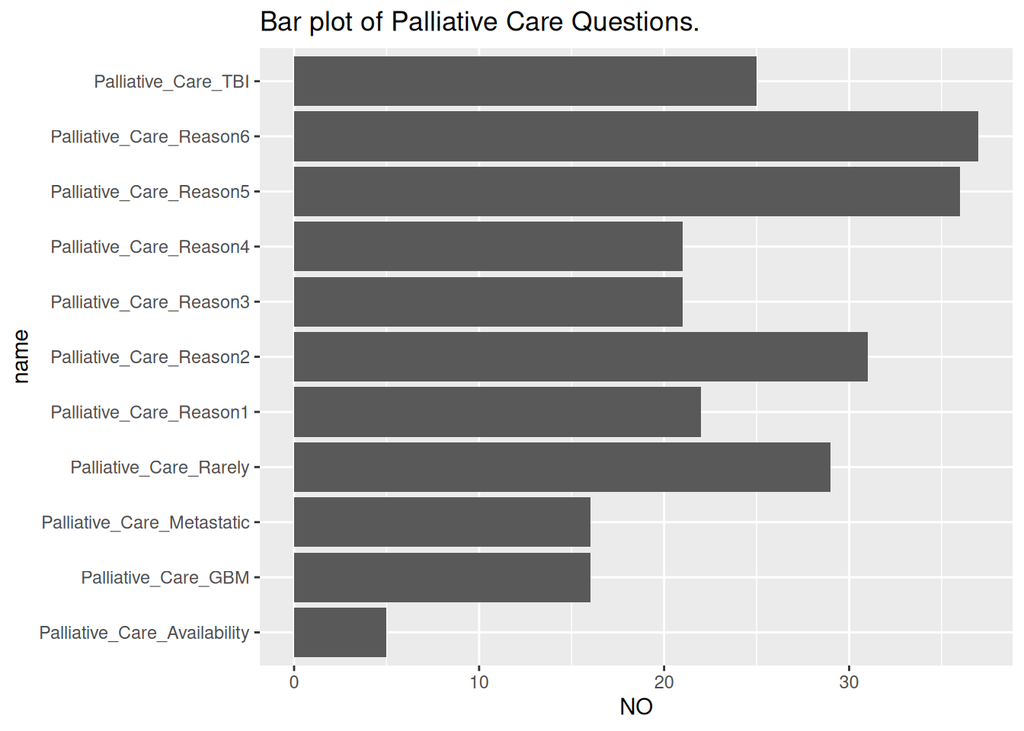

```r
pal <- df %>%
 select(
  Palliative_Care_Availability,
  Palliative_Care_TBI,
  Palliative_Care_GBM,
  Palliative_Care_Metastatic,
  Palliative_Care_Rarely,
  Palliative_Care_Reason1,
  Palliative_Care_Reason2,
  Palliative_Care_Reason3,
  Palliative_Care_Reason4,
  Palliative_Care_Reason5,
  Palliative_Care_Reason6
 ) %>%
 pivot_longer( c(
  Palliative_Care_Availability,
  Palliative_Care_TBI,
  Palliative_Care_GBM,
  Palliative_Care_Metastatic,
  Palliative_Care_Rarely,
  Palliative_Care_Reason1,
  Palliative_Care_Reason2,
  Palliative_Care_Reason3,
  Palliative_Care_Reason4,
  Palliative_Care_Reason5,
  Palliative_Care_Reason6
 )) %>%
 table() %>%
 as_tibble() %>%
 pivot_wider(names_from = value, values_from = n) %>%
 arrange(name)

ggplot(pal, aes( y = name, x = NO ) ) +
 geom_bar(stat="identity") +
 ggtitle( "Bar plot of Palliative Care Questions." )
```

Palliative_Care_Other: On which patient do you routinely consult palliative care? (check all that apply) x Other… (NO, free text)

```r
df %>% select( Palliative_Care_Other ) %>% table() %>% as_tibble()
```

```
## # A tibble: 3 × 2
##   Palliative_Care_Other                                           n
##   <chr>                                                       <int>
## 1 It's almost not possible to find palliative specialist here     1
## 2 Ne                                                             36
## 3 pediatrics brain tumours                                        1
```

Palliative_Care_Reason7: What are the reasons you consult palliative care? (check all that apply) Other (NO, free text)

```r
df %>% select( Palliative_Care_Reason7 ) %>% table() %>% as_tibble()
```

```
## # A tibble: 5 × 2
##   Palliative_Care_Reason7                                                 n
##   <chr>                                                               <int>
## 1 As previous                                                             1
## 2 Ne                                                                     34
## 3 None                                                                    1
## 4 to ease the family situation in the last month of their childs life     1
## 5 when I'm not able to set an adequate pain therapy                       1
```

## Depression

```r
describe( df = df, column_names = c("PHQ9"), caption = "PHQ9 Descriptive Statistics" )
```

PHQ9 Descriptive Statistics

| name | min | Q1 | median | Q3 | max | mean | sd |
| --- | --- | --- | --- | --- | --- | --- | --- |
| PHQ9 | 0 | 1.25 | 3 | 9 | 24 | 5.5 | 5.93 |

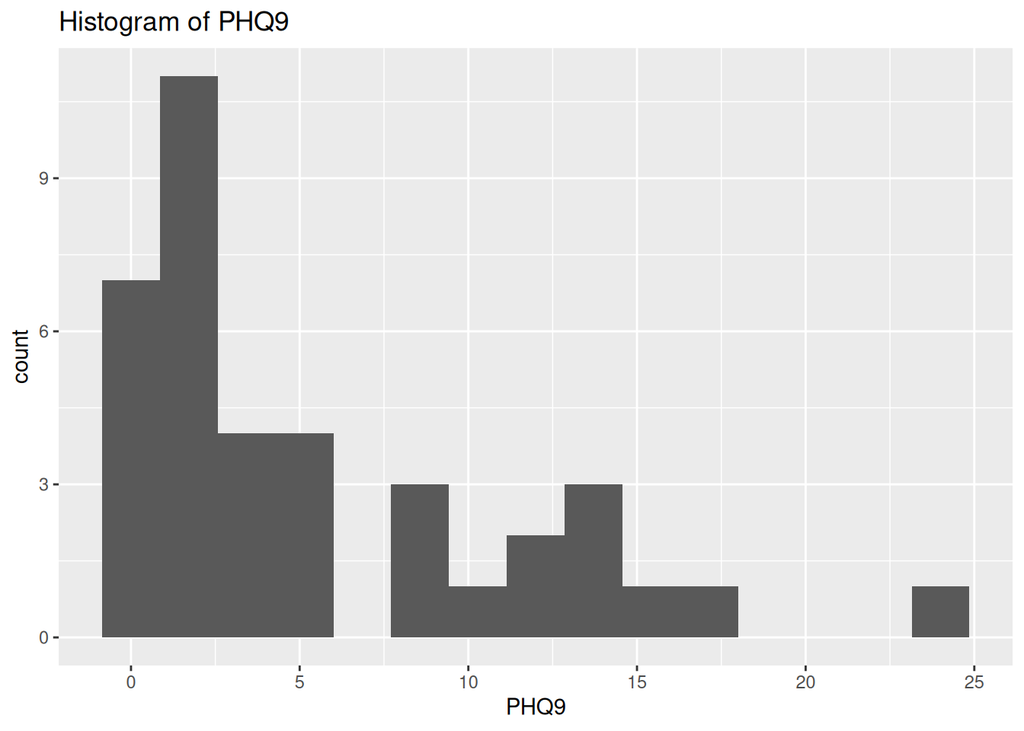

```r
ggplot( df, aes( x = PHQ9 ) ) +
 geom_histogram( bins = 15 ) +
 ggtitle( "Histogram of PHQ9" )
```

### Depression and Moral Distress

Scatter

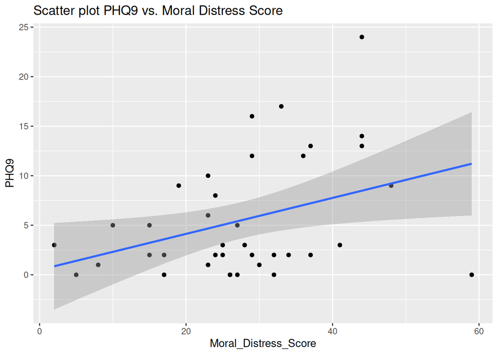

```r
ggplot( df, aes( x = Moral_Distress_Score, y = PHQ9 ) ) +
 geom_point() +
 geom_smooth(method = "lm" , formula = "y ~ x") +
 ggtitle( "Scatter plot PHQ9 vs. Moral Distress Score" )
```

Pearson’s correlation coefficient of Moral Distress Score and PHQ9:

```r
cor.test(df$PHQ9, df$Moral_Distress_Score)
```

```
##
##  Pearson's product-moment correlation
##
## data:  df$PHQ9 and df$Moral_Distress_Score
## t = 2.3724, df = 36, p-value = 0.02314
## alternative hypothesis: true correlation is not equal to 0
## 95 percent confidence interval:
##  0.05441738 0.61508486
## sample estimates:
##      cor
## 0.367704
```

Linear regression model of Moral Distress Score and PHQ9:

```r
model <- lm ( PHQ9 ~ Moral_Distress_Score, df)
summary(model)
```

```
##
## Call:
## lm(formula = PHQ9 ~ Moral_Distress_Score, data = df)
##
## Residuals:
##     Min      1Q  Median      3Q     Max
## -11.208  -4.171  -1.314   4.172  15.515
##
## Coefficients:
##                      Estimate Std. Error t value Pr(>|t|)
## (Intercept)           0.49901    2.29483   0.217   0.8291
## Moral_Distress_Score  0.18151    0.07651   2.372   0.0231 *
## ---
## Signif. codes:  0 '***' 0.001 '**' 0.01 '*' 0.05 '.' 0.1 ' ' 1
##
## Residual standard error: 5.591 on 36 degrees of freedom
## Multiple R-squared:  0.1352, Adjusted R-squared:  0.1112
## F-statistic: 5.628 on 1 and 36 DF,  p-value: 0.02314
```

### Depression and Burnout

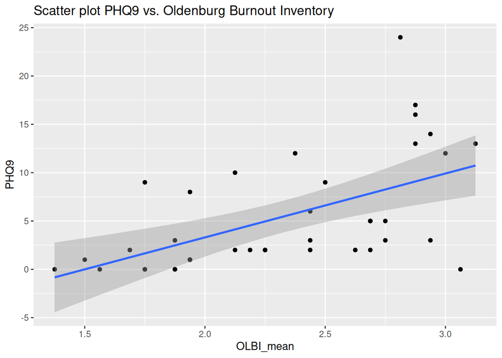

```r
ggplot( df, aes( x = OLBI_mean, y = PHQ9 ) ) +
 geom_point() +
 geom_smooth(method = "lm" , formula = "y ~ x") +
 ggtitle( "Scatter plot PHQ9 vs. Oldenburg Burnout Inventory" )
```

Pearson’s correlation coefficient of Burnout and PHQ9:

```r
cor.test(df$PHQ9, df$OLBI_mean)
```

```
##
##  Pearson's product-moment correlation
##
## data:  df$PHQ9 and df$OLBI_mean
## t = 4.0051, df = 36, p-value = 0.000297
## alternative hypothesis: true correlation is not equal to 0
## 95 percent confidence interval:
##  0.2863287 0.7430035
## sample estimates:
##       cor
## 0.5551927
```

Linear regression model of OLBI and PHQ9:

```r
model <- lm ( PHQ9 ~ OLBI_mean, df)
summary(model)
```

```
##
## Call:
## lm(formula = PHQ9 ~ OLBI_mean, data = df)
##
## Residuals:
##     Min      1Q  Median      3Q     Max
## -10.327  -2.929  -1.651   2.358  15.325
##
## Coefficients:
##             Estimate Std. Error t value Pr(>|t|)
## (Intercept)   -9.917      3.934  -2.521 0.016275 *
## OLBI_mean      6.610      1.650   4.005 0.000297 ***
## ---
## Signif. codes:  0 '***' 0.001 '**' 0.01 '*' 0.05 '.' 0.1 ' ' 1
##
## Residual standard error: 5.001 on 36 degrees of freedom
## Multiple R-squared:  0.3082, Adjusted R-squared:  0.289
## F-statistic: 16.04 on 1 and 36 DF,  p-value: 0.000297
```

Self-reported Burnout:

```r
kruskal.test(
    PHQ9 ~ Burnout,
    data = df
)
```

```
##
##  Kruskal-Wallis rank sum test
##
## data:  PHQ9 by Burnout
## Kruskal-Wallis chi-squared = 8.8387, df = 2, p-value = 0.01204
```

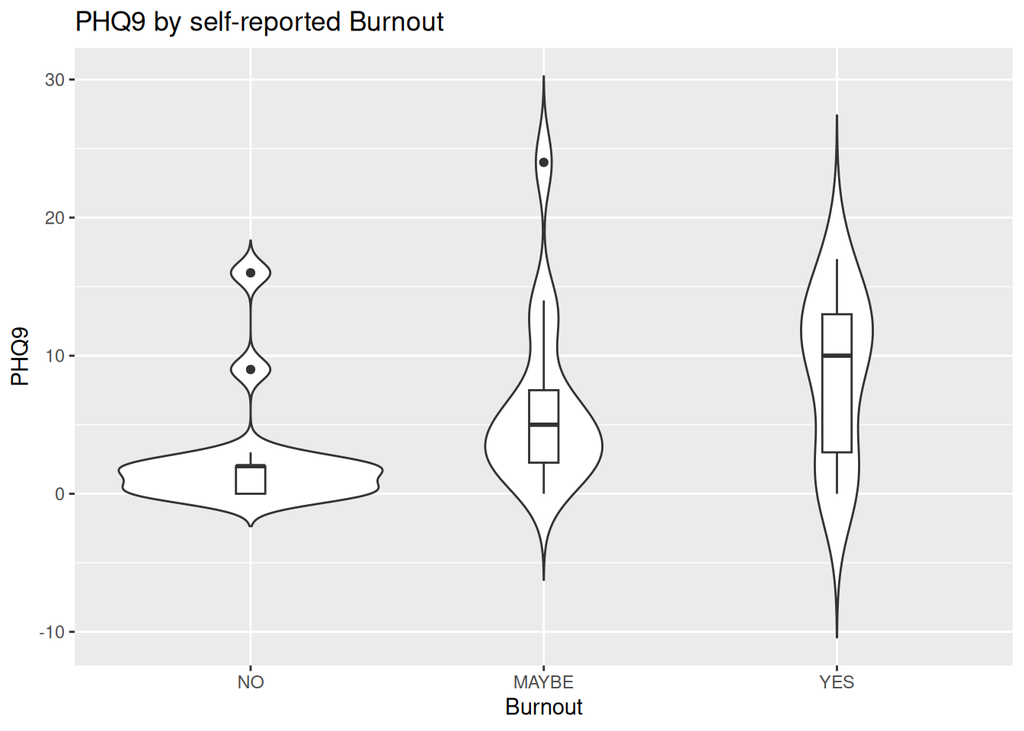

```r
ggplot( df, aes( x = Burnout, y = PHQ9 ) ) +
 geom_violin(trim = FALSE) +
 geom_boxplot( width = 0.1 ) +
 ggtitle( "PHQ9 by self-reported Burnout" )
```

### Depression Multivariate Regression Analysis

```r
model <- lm ( PHQ9 ~ Moral_Distress_Score + OLBI_mean, df)
summary(model)
```

```
##
## Call:
## lm(formula = PHQ9 ~ Moral_Distress_Score + OLBI_mean, data = df)
##
## Residuals:
##     Min      1Q  Median      3Q     Max
## -11.905  -2.889  -1.477   2.176  14.576
##
## Coefficients:
##                      Estimate Std. Error t value Pr(>|t|)
## (Intercept)          -9.99812    3.94784  -2.533  0.01596 *
## Moral_Distress_Score  0.06801    0.07771   0.875  0.38742
## OLBI_mean             5.84166    1.87445   3.116  0.00365 **
## ---
## Signif. codes:  0 '***' 0.001 '**' 0.01 '*' 0.05 '.' 0.1 ' ' 1
##
## Residual standard error: 5.017 on 35 degrees of freedom
## Multiple R-squared:  0.3231, Adjusted R-squared:  0.2844
## F-statistic: 8.351 on 2 and 35 DF,  p-value: 0.001083
```

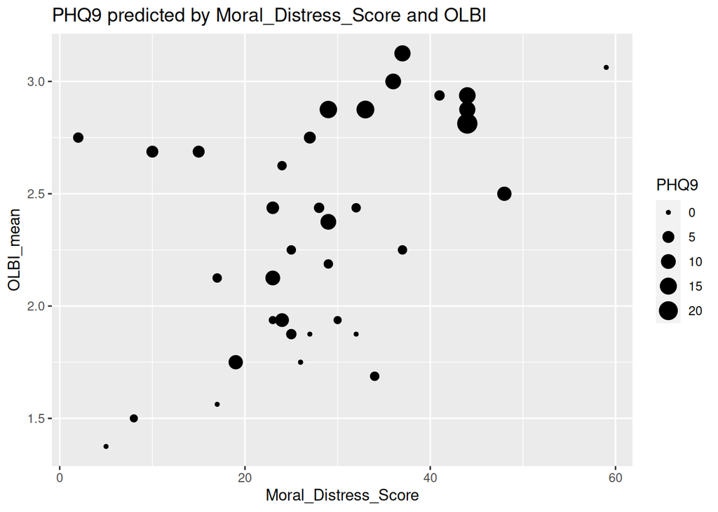

```r
ggplot( df, aes( x = Moral_Distress_Score, y = OLBI_mean, size = PHQ9 ) ) +
 geom_point() +
 ggtitle("PHQ9 predicted by Moral_Distress_Score and OLBI")
```